# ch-7-basic-statistics

Sonya Hua

January 15, 2018

For the examples, we’ll be using the data set mtcars A data frame with 32 observations on 11 variables.

[, 1] mpg Miles/(US) gallon [, 2] cyl Number of cylinders [, 3] disp Displacement (cu.in.) [, 4] hp Gross horsepower [, 5] drat Rear axle ratio [, 6] wt Weight (1000 lbs) [, 7] qsec 1/4 mile time [, 8] vs V/S [, 9] am Transmission (0 = automatic, 1 = manual) [,10] gear Number of forward gears [,11] carb Number of carburetors

### 7.1 Descriptive Statistics

```r
data(mtcars)

# Method 1: summary()

myvars <- c("mpg", "hp", "wt")
summary(mtcars[myvars])
```

```
##       mpg              hp              wt
##  Min.   :10.40   Min.   : 52.0   Min.   :1.513
##  1st Qu.:15.43   1st Qu.: 96.5   1st Qu.:2.581
##  Median :19.20   Median :123.0   Median :3.325
##  Mean   :20.09   Mean   :146.7   Mean   :3.217
##  3rd Qu.:22.80   3rd Qu.:180.0   3rd Qu.:3.610
##  Max.   :33.90   Max.   :335.0   Max.   :5.424
```

`sapply` used for matrices

```r
# Method 2: Define own functions and use sapply

mystats <- function(x, na.omit=F) {
  if (na.omit)
    x <- x[!is.na(x)]  # if we want to omit NA's
  m <- mean(x)
  n <- length(x)
  s <- sd(x)
  skew <- sum((x-m)^3/s^3)/n
  kurt <- sum((x-m)^3/s^4)/n -3
  return(c(n=n, mean=m, standard.dev=s, skew=skew, kurtosis=kurt))
}

sapply(mtcars[myvars],mystats)
```

```
##                    mpg          hp         wt
## n            32.000000  32.0000000 32.0000000
## mean         20.090625 146.6875000  3.2172500
## standard.dev  6.026948  68.5628685  0.9784574
## skew          0.610655   0.7260237  0.4231465
## kurtosis     -2.898679  -2.9894108 -2.5675372
```

```r
# Another example

centralstats <- function(x, na.omit=F) {
  if (na.omit)
    x <- x[!is.na(x)]
  m <- mean(x)
  med <- median(x)
  mode <- mode(x)
  return(c(mean=m, median=med, mode=mode))
}

sapply(mtcars[myvars], centralstats)
```

```
##        mpg         hp         wt
## mean   "20.090625" "146.6875" "3.21725"
## median "19.2"      "123"      "3.325"
## mode   "numeric"   "numeric"  "numeric"
```

The `describe()` function in the `Hmisc` package returns the number of variables and observations, the number of missing and unique values, and the five highest/lowest values

```r
# Method 3: Describe() from hmisc pkg

#install.packages("Hmisc")
library(Hmisc)
sdata <- mtcars[myvars]

describe(sdata)
```

```
## sdata
##
##  3  Variables      32  Observations
## ---------------------------------------------------------------------------
## mpg
##        n  missing distinct     Info     Mean      Gmd      .05      .10
##       32        0       25    0.999    20.09    6.796    12.00    14.34
##      .25      .50      .75      .90      .95
##    15.43    19.20    22.80    30.09    31.30
##
## lowest : 10.4 13.3 14.3 14.7 15.0, highest: 26.0 27.3 30.4 32.4 33.9
## ---------------------------------------------------------------------------
## hp
##        n  missing distinct     Info     Mean      Gmd      .05      .10
##       32        0       22    0.997    146.7    77.04    63.65    66.00
##      .25      .50      .75      .90      .95
##    96.50   123.00   180.00   243.50   253.55
##
## lowest :  52  62  65  66  91, highest: 215 230 245 264 335
## ---------------------------------------------------------------------------
## wt
##        n  missing distinct     Info     Mean      Gmd      .05      .10
##       32        0       29    0.999    3.217    1.089    1.736    1.956
##      .25      .50      .75      .90      .95
##    2.581    3.325    3.610    4.048    5.293
##
## lowest : 1.513 1.615 1.835 1.935 2.140, highest: 3.845 4.070 5.250 5.345 5.424
## ---------------------------------------------------------------------------
```

For `stat.desc()`, if `norm=T`, normal distribution statistics are returned including skewness, kurtosis, their p-values, and the Shapiro-Wilk test of normality. The Shapiro–Wilk test tests the null hypothesis that a sample x1, …, xn came from a normally distributed population.

```r
# Method4: stat.desc() from pastecs pkg

#install.packages("pastecs")
library(pastecs)
stat.desc(sdata, norm=T)
```

```
##                      mpg            hp           wt
## nbr.val       32.0000000   32.00000000  32.00000000
## nbr.null       0.0000000    0.00000000   0.00000000
## nbr.na         0.0000000    0.00000000   0.00000000
## min           10.4000000   52.00000000   1.51300000
## max           33.9000000  335.00000000   5.42400000
## range         23.5000000  283.00000000   3.91100000
## sum          642.9000000 4694.00000000 102.95200000
## median        19.2000000  123.00000000   3.32500000
## mean          20.0906250  146.68750000   3.21725000
## SE.mean        1.0654240   12.12031731   0.17296847
## CI.mean.0.95   2.1729465   24.71955013   0.35277153
## var           36.3241028 4700.86693548   0.95737897
## std.dev        6.0269481   68.56286849   0.97845744
## coef.var       0.2999881    0.46740771   0.30412851
## skewness       0.6106550    0.72602366   0.42314646
## skew.2SE       0.7366922    0.87587259   0.51048252
## kurtosis      -0.3727660   -0.13555112  -0.02271075
## kurt.2SE      -0.2302812   -0.08373853  -0.01402987
## normtest.W     0.9475647    0.93341934   0.94325772
## normtest.p     0.1228814    0.04880824   0.09265499
```

*Obs:* We fail to reject the null hypothesis that mpg and wt comes from a normally distributed population. This suggests mpg and wt are normally distributed, but not hp.

Kernal density plots are usually a much more effective way to view the distribution of a variable. Create the plot using plot(density(x)) where x is a numeric vector.

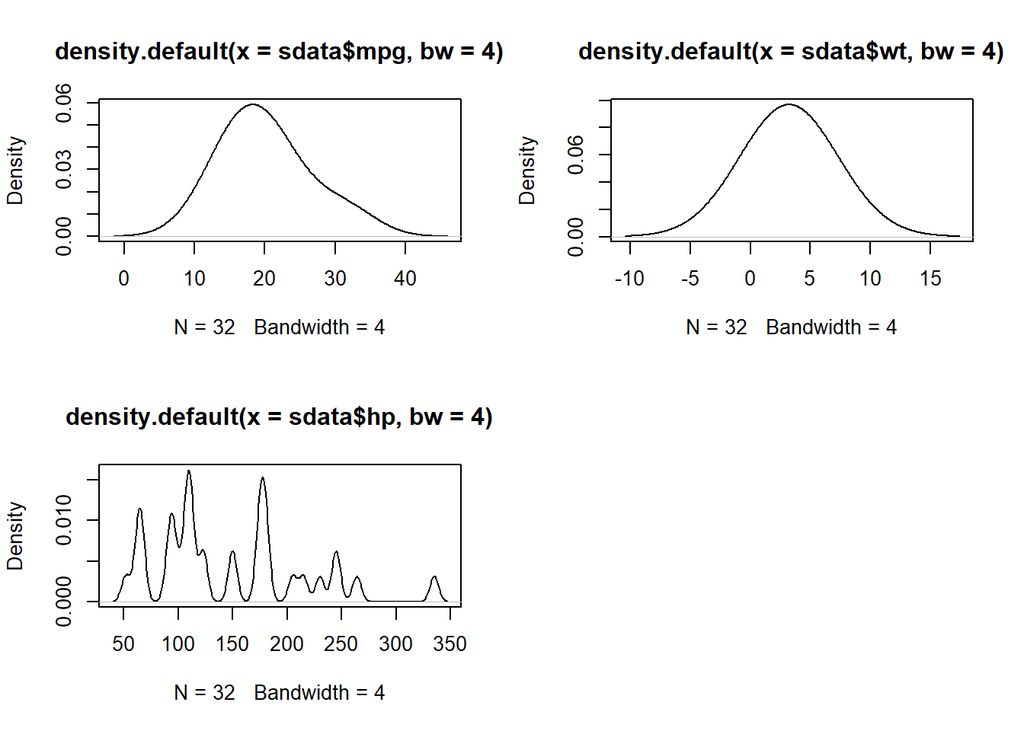

```r
par(mfrow=c(2,2))
plot(density(sdata$mpg, bw=4))
plot(density(sdata$wt, bw=4))
plot(density(sdata$hp, bw=4))
```

```r
#install.packages("psych")
library(psych)
describe(sdata)
```

```
##     vars  n   mean    sd median trimmed   mad   min    max  range skew
## mpg    1 32  20.09  6.03  19.20   19.70  5.41 10.40  33.90  23.50 0.61
## hp     2 32 146.69 68.56 123.00  141.19 77.10 52.00 335.00 283.00 0.73
## wt     3 32   3.22  0.98   3.33    3.15  0.77  1.51   5.42   3.91 0.42
##     kurtosis    se
## mpg    -0.37  1.07
## hp     -0.14 12.12
## wt     -0.02  0.17
```

*Skewness* is a measure of symmetry, or more precisely, the lack of symmetry. A distribution, or data set, is symmetric if it looks the same to the left and right of the center point.

*Kurtosis* is a measure of whether the data are heavy-tailed or light-tailed relative to a normal distribution.

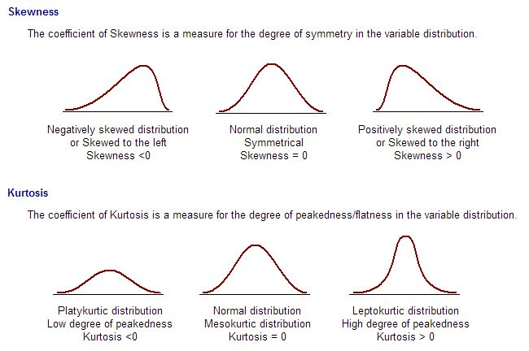

There are 2 versions of `describe()` based on packages Hmisc and psych. To specify which package to use do: `Hmisc::describe(sdata)`

### 7.1.3 Descriptive Stats by Group

We can usage `aggregate()` for single functions and `by=list(am=mtcars$am)` to specify we want a caolumn called `am` and the means to be grouped by this column

```r
mtcars
```

```
##                      mpg cyl  disp  hp drat    wt  qsec vs am gear carb
## Mazda RX4           21.0   6 160.0 110 3.90 2.620 16.46  0  1    4    4
## Mazda RX4 Wag       21.0   6 160.0 110 3.90 2.875 17.02  0  1    4    4
## Datsun 710          22.8   4 108.0  93 3.85 2.320 18.61  1  1    4    1
## Hornet 4 Drive      21.4   6 258.0 110 3.08 3.215 19.44  1  0    3    1
## Hornet Sportabout   18.7   8 360.0 175 3.15 3.440 17.02  0  0    3    2
## Valiant             18.1   6 225.0 105 2.76 3.460 20.22  1  0    3    1
## Duster 360          14.3   8 360.0 245 3.21 3.570 15.84  0  0    3    4
## Merc 240D           24.4   4 146.7  62 3.69 3.190 20.00  1  0    4    2
## Merc 230            22.8   4 140.8  95 3.92 3.150 22.90  1  0    4    2
## Merc 280            19.2   6 167.6 123 3.92 3.440 18.30  1  0    4    4
## Merc 280C           17.8   6 167.6 123 3.92 3.440 18.90  1  0    4    4
## Merc 450SE          16.4   8 275.8 180 3.07 4.070 17.40  0  0    3    3
## Merc 450SL          17.3   8 275.8 180 3.07 3.730 17.60  0  0    3    3
## Merc 450SLC         15.2   8 275.8 180 3.07 3.780 18.00  0  0    3    3
## Cadillac Fleetwood  10.4   8 472.0 205 2.93 5.250 17.98  0  0    3    4
## Lincoln Continental 10.4   8 460.0 215 3.00 5.424 17.82  0  0    3    4
## Chrysler Imperial   14.7   8 440.0 230 3.23 5.345 17.42  0  0    3    4
## Fiat 128            32.4   4  78.7  66 4.08 2.200 19.47  1  1    4    1
## Honda Civic         30.4   4  75.7  52 4.93 1.615 18.52  1  1    4    2
## Toyota Corolla      33.9   4  71.1  65 4.22 1.835 19.90  1  1    4    1
## Toyota Corona       21.5   4 120.1  97 3.70 2.465 20.01  1  0    3    1
## Dodge Challenger    15.5   8 318.0 150 2.76 3.520 16.87  0  0    3    2
## AMC Javelin         15.2   8 304.0 150 3.15 3.435 17.30  0  0    3    2
## Camaro Z28          13.3   8 350.0 245 3.73 3.840 15.41  0  0    3    4
## Pontiac Firebird    19.2   8 400.0 175 3.08 3.845 17.05  0  0    3    2
## Fiat X1-9           27.3   4  79.0  66 4.08 1.935 18.90  1  1    4    1
## Porsche 914-2       26.0   4 120.3  91 4.43 2.140 16.70  0  1    5    2
## Lotus Europa        30.4   4  95.1 113 3.77 1.513 16.90  1  1    5    2
## Ford Pantera L      15.8   8 351.0 264 4.22 3.170 14.50  0  1    5    4
## Ferrari Dino        19.7   6 145.0 175 3.62 2.770 15.50  0  1    5    6
## Maserati Bora       15.0   8 301.0 335 3.54 3.570 14.60  0  1    5    8
## Volvo 142E          21.4   4 121.0 109 4.11 2.780 18.60  1  1    4    2
```

```r
aggregate(sdata, by=list(am=mtcars$am), mean)
```

```
##   am      mpg       hp       wt
## 1  0 17.14737 160.2632 3.768895
## 2  1 24.39231 126.8462 2.411000
```

```r
aggregate(sdata,by=list(am=mtcars$am), sd)
```

```
##   am      mpg       hp        wt
## 1  0 3.833966 53.90820 0.7774001
## 2  1 6.166504 84.06232 0.6169816
```